# STA 363 Fall 2025

Take-Home Exam 2

## Data

Education researchers wonder which factors most affect the completion rates at U.S. colleges. Using the IPEDS database containing data from 1310 institutions over the years 2002-2009 (IPEDS), the following variables were assembled in `colleges.csv`:

- `id` = unique identification number for each college or university

Response:

- `rate` = completion rate (number of degrees awarded per 100 students enrolled)

Level 1 predictors:

- `year`
- `instpct` = percentage of students who receive an institutional grant
- `instamt` = typical amount of an institutional grant among recipients (in $1000s)

Level 2 predictors:

- `faculty` = mean number of full-time faculty per 100 students during 2002-2009
- `tuition` = mean yearly tuition during 2002-2009 (in $1000s)

**NOTE: The included code will filter out all schools with only 1 year of data.**

**Primary Question of Interest**

Identify important factors to explain college completion rates. Of the important factors, explain how they affect the completion rates.

**Data and Library Code (Click to Collapse)**

```r
library(tidymodels)
library(tidyverse)
library(DataExplorer)
library(ggridges)
library(readxl)
library(gridExtra)
library(lme4)
library(broom.mixed)
library(kableExtra)

colleges <- read_csv("colleges.csv")

# remove 3 schools with rates above 100
# and median center others (except year at first year)
colleges <- colleges |>
              filter(!(id %in% c(198109,146755,233912))) |>
              mutate(year.c = year - 2002,
                instamt.c = instamt - 5.88,
                instpct.c = instpct - 74.0,
                tuition.c = tuition - 15.11,
                faculty.c = faculty - 5.36)

col_list <- colleges |> count(id) |>filter(n>1)

colleges <- colleges |> filter(id %in% col_list$id)
```

## Questions

1. *Complete an exploratory data analysis.* You do **not** need to replicate any of the included EDA on your test. Reference the included plots using the figure numbers.
2. *Fit appropriate regression models to predict the completion rate.* Explain your process and the decisions you make. Use plots and other analyses to explain why you include or remove variables from your models.
3. *Assess your final chosen model.* Check the model condition for your final model and discuss any use limitations.
4. *Interpret coefficients from your chosen model.* Interpret all of the coefficients in your final model.

## Submission

When you are finished with your exam, render the final document. Once rendered, you can download your file by:

- Finding the .html file in your File pane (on the bottom right of the screen)
- Click the check box next to the file
- Click the blue gear above and then click “Export” to download
- Submit your final html document to the exam spot on [Moodle](https://moodle.cornellcollege.edu/mod/assign/view.php?id=346406)

## Code

### EDA Code

```
# A tibble: 1 × 9
   rows columns discrete_columns continuous_columns all_missing_columns
  <int>   <int>            <int>              <int>               <int>
1  7848      15                2                 13                   0
# ℹ 4 more variables: total_missing_values <int>, complete_rows <int>,
#   total_observations <int>, memory_usage <dbl>
```

```
Rows: 7,848
Columns: 15
$ ...1      <dbl> 2, 3, 4, 5, 6, 7, 8, 9, 10, 12, 13, 14, 15, 16, 17, 18, 19, …
$ id        <dbl> 446048, 446048, 446048, 445188, 445188, 443410, 443410, 4434…
$ year      <dbl> 2006, 2007, 2008, 2008, 2009, 2005, 2006, 2007, 2008, 2006, …
$ rate      <dbl> 13.949032, 24.836729, 28.798360, 4.072385, 10.661386, 15.993…
$ instpct   <dbl> 74, 95, 55, 65, 75, 2, 7, 22, 17, 24, 21, 27, 78, 93, 38, 37…
$ instamt   <dbl> 6.552, 8.178, 11.521, 6.417, 6.642, 0.500, 1.985, 3.420, 3.6…
$ instname  <chr> "Ave Maria University", "Ave Maria University", "Ave Maria U…
$ state     <chr> "FL", "FL", "FL", "CA", "CA", "WA", "WA", "WA", "WA", "CA", …
$ tuition   <dbl> 4.364000, 4.364000, 4.364000, 4.580750, 4.580750, 3.925000, …
$ faculty   <dbl> 14.829452, 14.829452, 14.829452, 5.334042, 5.334042, 4.72061…
$ year.c    <dbl> 4, 5, 6, 6, 7, 3, 4, 5, 6, 4, 5, 6, 2, 3, 1, 2, 3, 4, 5, 6, …
$ instamt.c <dbl> 0.672, 2.298, 5.641, 0.537, 0.762, -5.380, -3.895, -2.460, -…
$ instpct.c <dbl> 0, 21, -19, -9, 1, -72, -67, -52, -57, -50, -53, -47, 4, 19,…
$ tuition.c <dbl> -10.746000, -10.746000, -10.746000, -10.529250, -10.529250, …
$ faculty.c <dbl> 9.46945220, 9.46945220, 9.46945220, -0.02595815, -0.02595815…
```

Count Table of Number of Years and Number of Schools with That Number of Years

| Number of Years in Data | Number of Schools |
| --- | --- |
| 2 | 52 |
| 3 | 71 |
| 4 | 105 |
| 5 | 114 |
| 6 | 130 |
| 7 | 335 |
| 8 | 427 |

Correlation Matrix

|  | colleges.rate | colleges.year | colleges.instpct | colleges.instamt |
| --- | --- | --- | --- | --- |
| colleges.rate | 1.0000000 | 0.0433947 | 0.2256113 | 0.2228953 |
| colleges.year | 0.0433947 | 1.0000000 | 0.0337770 | 0.1895445 |
| colleges.instpct | 0.2256113 | 0.0337770 | 1.0000000 | 0.3699199 |
| colleges.instamt | 0.2228953 | 0.1895445 | 0.3699199 | 1.0000000 |

```
                     aid.lev2.meanrate aid.lev2.meaninstpct
aid.lev2.meanrate            1.0000000            0.2415431
aid.lev2.meaninstpct         0.2415431            1.0000000
aid.lev2.meaninstamt         0.2425387            0.3720573
                     aid.lev2.meaninstamt
aid.lev2.meanrate               0.2425387
aid.lev2.meaninstpct            0.3720573
aid.lev2.meaninstamt            1.0000000
```

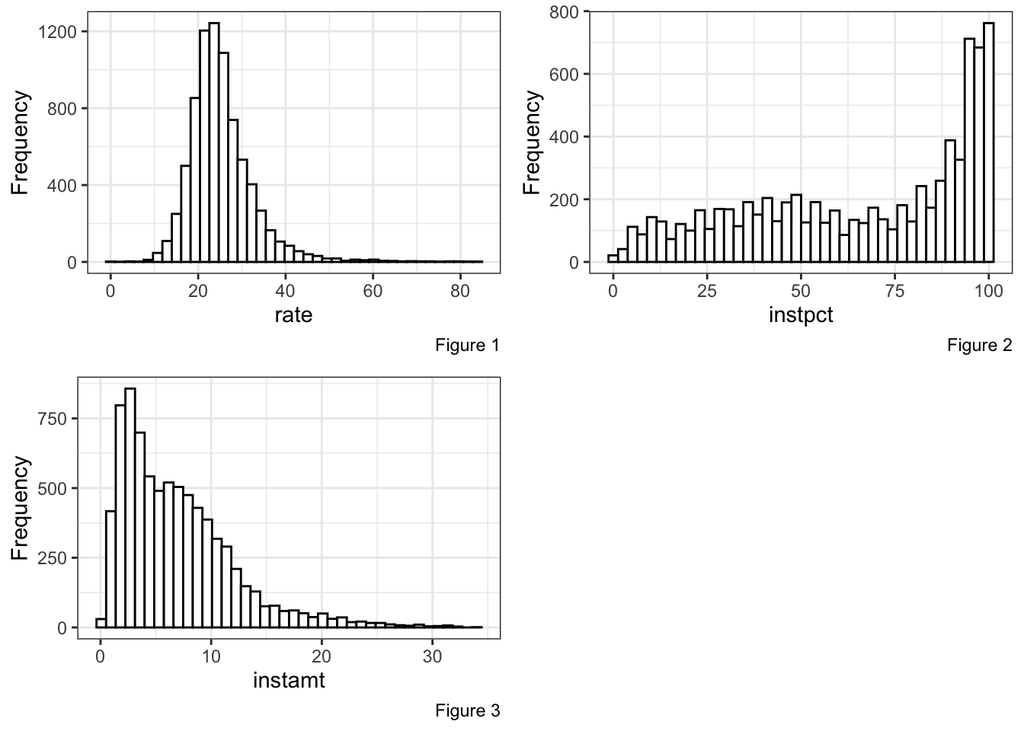

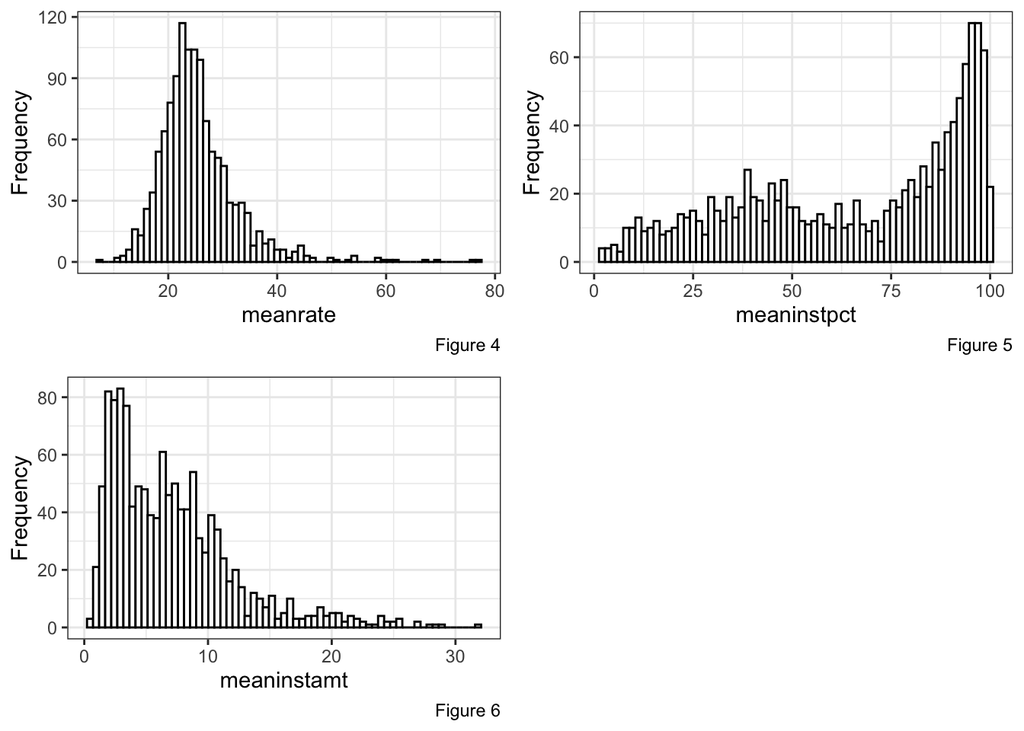

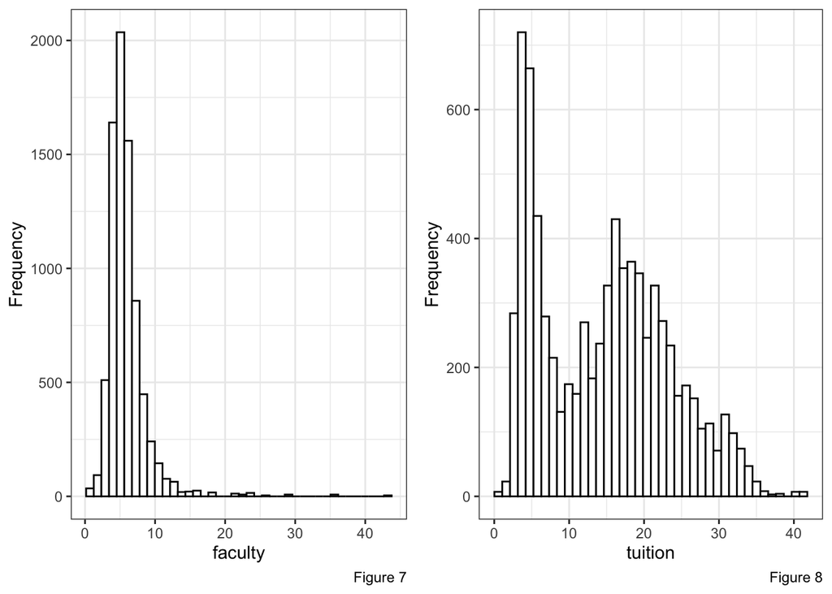

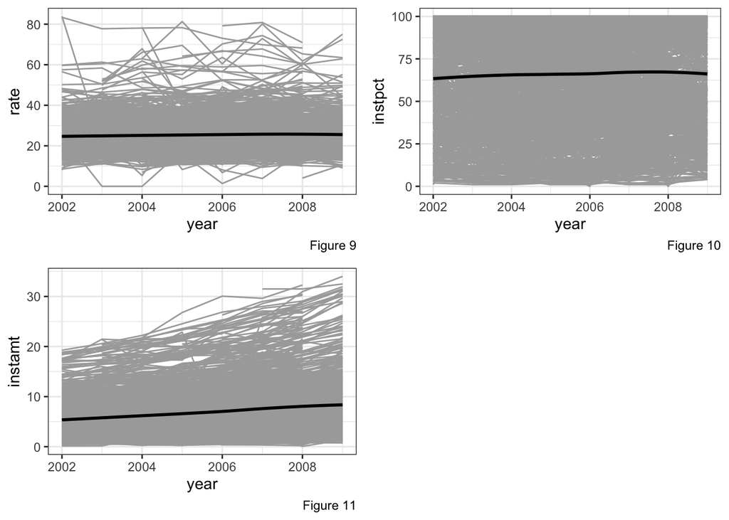

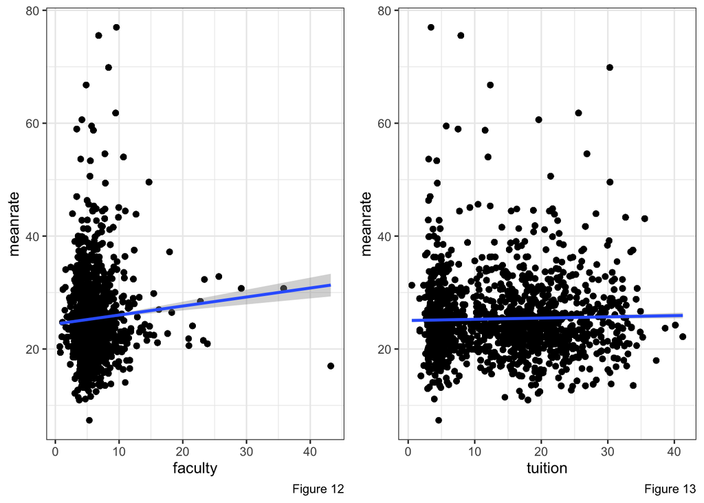